# Making slides with pandoc and revealjs

Miguel Angel Marco Buzunariz

Zaragoza, June 2019

# Overview

## Advantages

- Faster workflow
  - And reusable (can export to latex/beamer/pdf/html…)
- Don’t depend on pdf viewer
- Can include videos, and animations
- Zoomable
- Can use speaker notes, and overview
- Smaller files (plus dependencies)

## Disadvantages

- Some latex-beamer features might be missing
- Bigger files (if self-contained)
- If we use a theme with upper title bars, slides are not vertically centered

## Requirements

You need

- install pandoc
- copy revealjs on your directory
  - copy the beamer.css file into revealjs/css/theme/
- copy katex on your directory (if you want to be able to compile without internet connection)

## Workflow

Write a markdown file. And then execute

```
pandoc example.md -o example.html \
       -t revealjs \
       --katex=./katex/  \
       --standalone \
       -V theme=beamer \
       -V transition=none  \
       -i --slide-level 2 \
       --self-contained
```

Thats it!

# Markdown syntax

## Sections and slides

A line like

```
# This section name
```

Will make a slide with a big centered title (for sections)

A line like

```
## This slide title
```

Will make a slide with an upper title bar.

## Lists

Lists are done like this

```markdown
- First item
- Second item
  - Subitem inside second item
  - Second subitem
- Thirthd item
```

- First item
- Second item
  - Subitem inside second item
  - Second subitem
- Thirthd item

## Fragments

To make a part of the slide appear with a click, just separate it with a line with three dots separated by spaces. That is, the code:

```markdown
First paragraph that i see.

. . .

This second paragraph appears as I click
```

Has this effect:

First paragraph that i see.

This second paragraph appears as I click

## Latex content

Latex content can be inserted normally, thanks to katex.

So this:

```markdown
The formula for the volume of a sphere is $\frac{4 \pi r^3}{3}$.
```

Will produce this:

The formula for the volume of a sphere is $\frac{4 \pi r^3}{3}$.

## Latex content

Display math is also possible. For instance like this:

```markdown
$$
\int_{0}^{+\infty} \frac{1}{x}dx=+\infty
$$
```

$$\int_{0}^{+\infty} \frac{1}{x}dx=+\infty$$

## Theorem boxes

The code

```markdown
::: thm
<!-- -->
### **Theorem:**

The ring of polynomials over a field is noetherian.
:::
```

will be seen as

### **Theorem:**

The ring of polynomials over a field is noetherian.

## Images

You can embed images in two ways. One is using markdown syntax:

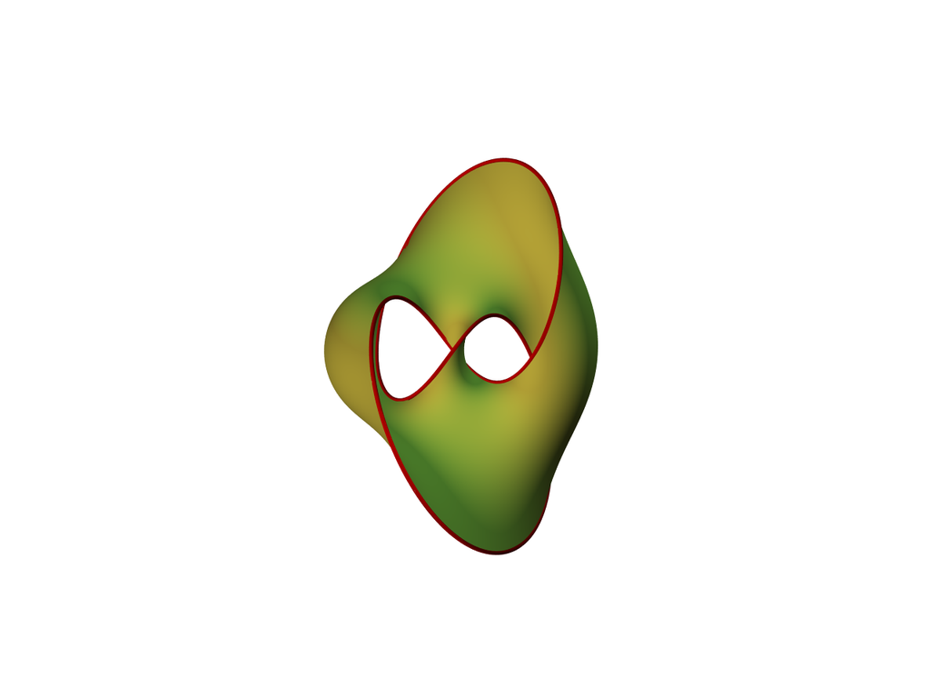

```markdown
![](fibramilnor.png)
```

## Images

You can embed images in two ways. The second one is using html syntax:

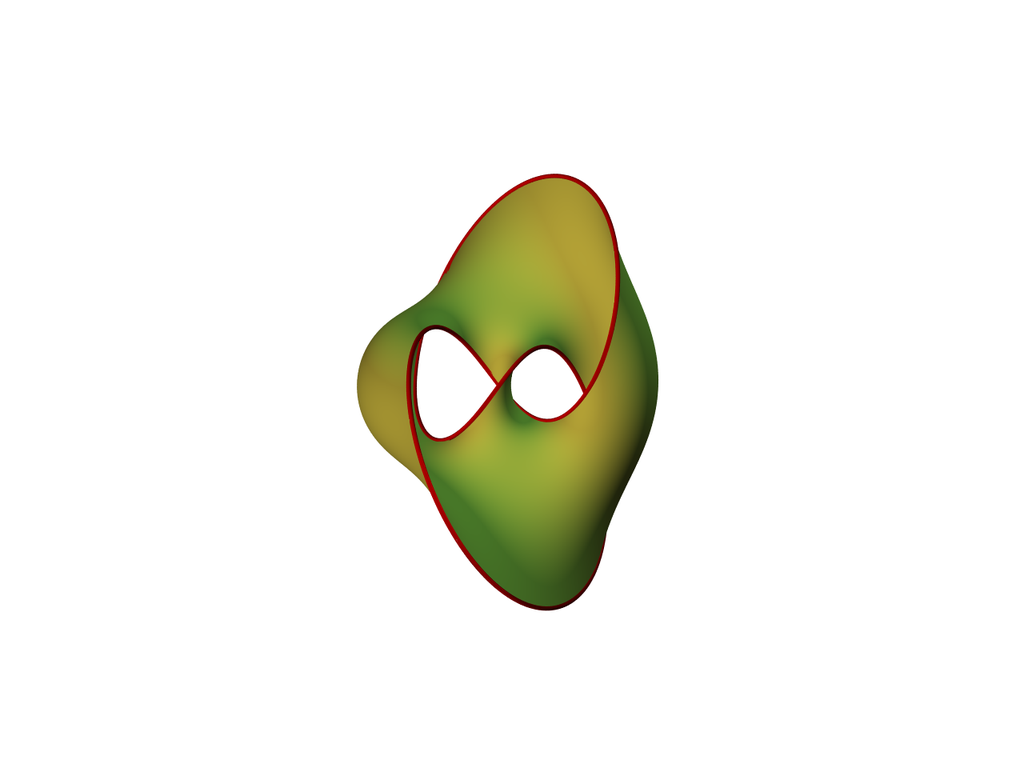

```markdown
<img data-src="fibramilnor.png" />
```

## Videos

Videos can be embedded using html syntax:

```markdown
<video data-autoplay src="fibramilnor.webm"/>
```

[video not shown]

# Pandoc options

## Transitions

- None
- Fade
- Slide
- Convex
- Concave
- Zoom

## Themes

- beige
- black
- blood
- league
- moon
- night
- serif
- simple
- sky
- solarized
- white
- beamer (not by default)

They are stored in the `/reveal.js/css/theme/` directory.